# My visual data story on Youtube ads

Seulgi Lim

## Introduction

Over several days we collected data based on the ads we received on Youtube. Data was collected by me updating the Google form whenever I get an ad. The data was collected on Google Form and was analysed further.

## Data cleansing

There were some data points that says it had been seen before however there was ad length that matched. There were also data points that didn’t follow Youtube guidelines which we also removed. Data points 22, 31, 36 were removed.

## Bar graph showing the relationship between the different ad lengths and ad type(skippable or non-skippable)

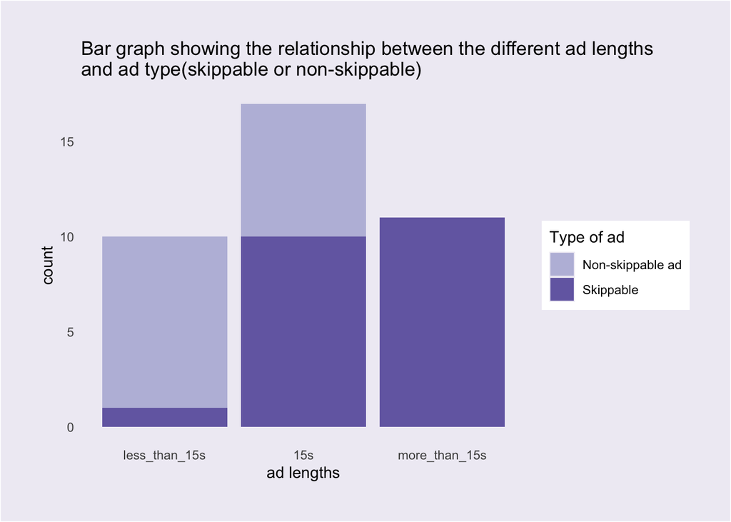

We had manipulated the data to create a new variable called ad lengths. This is an categorical variable grouped by the length of the ad. The bar graph showed that if the ad was less than 15 seconds it was most likley to be non-skippable. If the ad was 15s the chance of being skippable or non skippable was close to 50%. If the ad was more than 15s it was 100% skippable. What we found from our data collection matches up with Youtube guidelines for ads.

## Point graph showing the relationship between the ad lengths(s) and ad previously seen(yes or no)

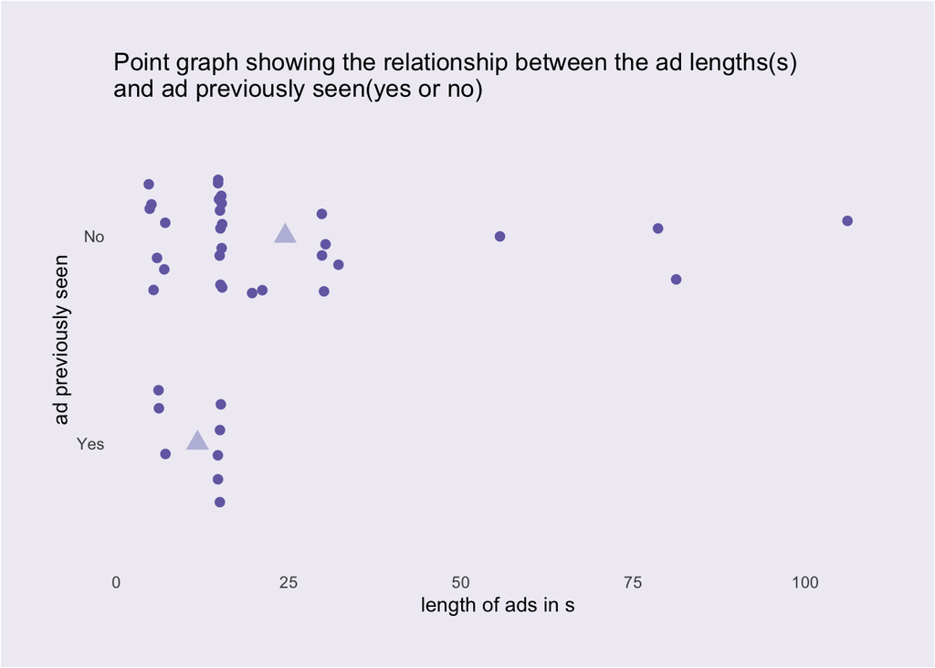

The graph shows the relationship between the ad lengths(s) and ad previously seen(yes or no). The light purple triangle shows the median ad length when the ad had been previously seen and when it hadn’t. The dark circle shows all the datapoint ploted. We can see from the plot that ads hadn’t previously seen had a higher average ad length than ads that were seen before. We can also see that when the ads hadn’t previously seen there was a right skew distribution.

## Point graph showing the relationship between the ad lengths(s) and ad previously seen(yes or no)

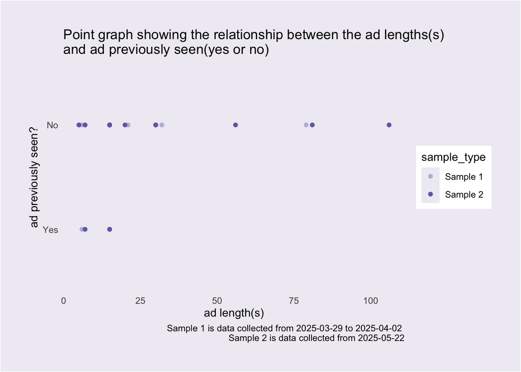

The graph shows a similar relationship as Point graph showing the relationship between the ad lengths(s) and ad previously seen(yes or no). However it is also showing the difference between the two samples. We have collected the sample over two periods 2025-03-29 to 2025-04-02 and 2025-05-22. We mutated the data using functions from lubridate like floor_date and ifelse to group them into Sample 1 and 2. We can see that similar ad lengths were observed for Sample 1 and 2.